# Report_for_Introduction_to_Bayesian_Analysis_in_R

Konstantin Ibadullaev ; 63072

8/27/2021

```r
library(knitr)
library(dplyr)
library(magrittr)
library(extraDistr)
library("png")
```

# Task 1. Discretization methods.

## Problem set.

Correlating tuff levels. Compute the probability of obtaining brown rock from any of 3 tuff levels $Pr[brown]$ on F.

## Initial preparations.

The provided data presented as number of rocks of 3 different types on each of 3 different levels. There’s also provided probability of picking a particular level, i.e that a particular level was selected to obtain any of 3 rock types.

[figure not shown]

```
                                Figure 1.
```

```r
# Visualize the task

tsk<- readPNG("task1.png")
plot.new()
rasterImage(tsk,0,0,1,1)
```

## Theoretical background.

One starts with check of probabilities $Pr[F1], Pr[F2], Pr[F3]$. They have to form the full group and be mutual exclusive, i.e $Pr[F1]+ Pr[F2]+ Pr[F3] =1/4+1/2+1/4 = 1$. From that follows, that one of 3 levels will be picked.

Mainly, one should implement Bayes formula in order to get any probability of obtaining any single particular rock type from a desired level. $P[B_i | A] = \frac{P[B_i]P[A|B_i]}{\sum_{i=1}^{n} {P[B_i]P[A|B_i]} }$, where :

- $P[B_i]$ - probability of $Pr[F_i]$
- $P[B_i]P[A|B_i]$ - likelihood
- $\sum_{i=1}^{n} {P[B_i]P[A|B_i]}$ is a probability of a specific rock type, also known as $P[A_i] = \sum_{i=1}^{n} {P[B_i]P[A|B_i]}$ .

## Workflow.

The last probability is exactly what required for solution. It’s worth noting, that one can also find a probability of a specific rock type on a defined level using mentioned formula. But here is solely $P[A_i] = \sum_{i=1}^{n} {P[B_i]P[A|B_i]}$ to be computed.

### Fill the data frame with dipslayed data of the task.

One fills the number of pieces of each rock type on the each level and computes total number of specimens.

```r
#

# distribution of rocks due to levels
df = data.frame(Level =factor(c("F1", "F2", "F3")) ,
                Brown=c(5,1,1), Green=c(2, 1, 6), White=c(1,2,9),
                prob_F = c(0.25, 0.5,0.25))
total = c(sum(df[1,c(2:4)]),sum(df[2,c(2:4)]),sum(df[3,c(2:4)]))
df = cbind(df,total)
df
```

```
##   Level Brown Green White prob_F total
## 1    F1     5     2     1   0.25     8
## 2    F2     1     1     2   0.50     4
## 3    F3     1     6     9   0.25    16
```

### Compute frequencies.

Here’s the data frame with computed frequencies of each rock type on each level.

```r
# probabilities
prbs_ = data.frame(Level = factor(c("F1", "F2", "F3")),
                  Brown = df$Brown %o% 1/df$total,
                  Green = df$Green %o% 1/df$total,
                  White = df$White %o% 1/df$total,
                  total = df$total)
prbs_
```

```
##   Level  Brown Green  White total
## 1    F1 0.6250 0.250 0.1250     8
## 2    F2 0.2500 0.250 0.5000     4
## 3    F3 0.0625 0.375 0.5625    16
```

### Compute $Pr[colour]$

Now one can compute required probabilities for desired rock type. Since it’s not complicated, probabilities for all 3 rock types are calculated.

```r
# to obtain brown rock from F
Pr_brown = df[1,5] * prbs_[1,2] + df[2,5] * prbs_[2,2] + df[3,5] * prbs_[3,2]
(paste(" The probability for the brown rock type :",Pr_brown))
```

```
## [1] " The probability for the brown rock type : 0.296875"
```

```r
# to obtain green rock from F
Pr_green = df[1,5] * prbs_[1,3] + df[2,5] * prbs_[2,3] + df[3,5] * prbs_[3,3]

(paste(" The probability for the green rock type :",Pr_green))
```

```
## [1] " The probability for the green rock type : 0.28125"
```

```r
# to obtain white rock from F
Pr_white = df[1,5] * prbs_[1,4] + df[2,5] * prbs_[2,4] + df[3,5] * prbs_[3,4]
(paste(" The probability for the white rock type :",Pr_white))
```

```
## [1] " The probability for the white rock type : 0.421875"
```

In order to prove correctness of calculations, it’s desired to check whether those probabilities form the full group and mutually exclusive. It’s obvious that one gets one of 3 rock types. Probability of getting nothing is not considered. So, $P[color] = {P[brown]+P[green]+ P[white]} = 1$ .

```r
#Join into the table
Pr_colour = data.frame(
  Level = factor("F") ,
  Brown=Pr_brown,
  Green=Pr_green,
  White=Pr_white,
  prob_F = "---",
  total = sum(Pr_brown, Pr_green, Pr_white))
# as one can see result is proved as sum of probabilities for each rock equals 1
df = rbind(df, Pr_colour)
df
```

```
##   Level    Brown   Green    White prob_F total
## 1    F1 5.000000 2.00000 1.000000   0.25     8
## 2    F2 1.000000 1.00000 2.000000    0.5     4
## 3    F3 1.000000 6.00000 9.000000   0.25    16
## 4     F 0.296875 0.28125 0.421875    ---     1
```

As one can see result is proved as sum of probabilities for each rock equals 1 as well as sum along the rows for each F.

```r
F = rbind(prbs_, Pr_colour[,-5]) %>%
  mutate(total_Pr= c(sum(prbs_[1,c(2:4)]),
                  sum(prbs_[2,c(2:4)]),
                  sum(prbs_[3,c(2:4)]),
                  sum(Pr_brown, Pr_green, Pr_white)))

F = F[, -5]
F
```

```
##   Level    Brown   Green    White total_Pr
## 1    F1 0.625000 0.25000 0.125000        1
## 2    F2 0.250000 0.25000 0.500000        1
## 3    F3 0.062500 0.37500 0.562500        1
## 4     F 0.296875 0.28125 0.421875        1
```

As final output, one obtains:

```r
results = F[4,]
results
```

```
##   Level    Brown   Green    White total_Pr
## 4     F 0.296875 0.28125 0.421875        1
```

# Task 2. Conjugate Priors.

## Problem set.

1. Compute posterior hyperparameters
2. What is the probability of no earthquake next year?

## Initial preparations.

The data is presented as spreadsheet CSV-file: earthquakes_USGS.csv One has interest in recordings which satisfy following requirements:

1. The earthquake hazard of magnitude is higher than 6.
2. Regions of interest are Northwestern Europe and Mediterranean.

## Theoretical background.

Poisson distribution relates to one of discrete types of probability distributions and models the number of occurring events per time interval. The average time between events is known but the exact timing of events is random. Furthermore, it’s used for series of events with a low probability( p<0.1).

- Poisson distribution $PO(\lambda) = \frac{\lambda^k * e^{-\lambda}}{k!}$
- Poisson process $X \sim PO(\lambda)$.
- Intensity of event flow/ average number of event per time period is $\lambda$

Since the rate of occurrence of earthquakes remains the same during the whole year, the hazard rate doesn’t change as well. Due to that fact and considering that prior has a gamma distribution, one can model earthquakes with Poisson distribution and conjugacy principle yields that posterior has a negative binomial distribution.

Conjugate priors help to reduce Bayesian updating. That is, only hyperparameters of priors are updated, avoiding integral calculations. Though calculation of posterior for each $\theta$ makes computations of the posterior expensive. Using conjugacy one can avoid that kind of computations by adding the number of acceptances and rejections to the existing parameters $\alpha$ and $\beta$. One should consider that multiplication is more expensive than summation.

## Workflow.

### Load the dataset and explore it.

```r
# load data
eqk = read.csv("earthquakes_USGS.csv", skip=2)
#check
names(eqk)
```

```
##  [1] "year"        "month"       "day"         "hour"        "minute"
##  [6] "second"      "latitude"    "longitude"   "focal_depth" "region"
## [11] "magnitude"
```

```r
kable(head(eqk))
```

| year | month | day | hour | minute | second | latitude | longitude | focal_depth | region | magnitude |
| --- | --- | --- | --- | --- | --- | --- | --- | --- | --- | --- |
| 1900 | 1 | 5 | 19 | 0 | 0 | -3.0 | 102.0 | 0 | 274 | 7.0 |
| 1900 | 1 | 11 | 9 | 7 | 0 | -5.0 | 148.0 | 0 | 192 | 7.0 |
| 1900 | 1 | 18 | 7 | 46 | 0 | 44.5 | 148.5 | 35 | 221 | 6.7 |
| 1900 | 1 | 20 | 6 | 33 | 0 | 20.0 | -105.0 | 0 | 55 | 7.3 |
| 1900 | 1 | 31 | 19 | 22 | 0 | 48.0 | 146.0 | 450 | 663 | 7.5 |
| 1900 | 4 | 24 | 23 | 16 | 0 | 27.0 | 126.5 | 35 | 234 | 6.9 |

Short statistic summary.

```r
summary(eqk)
```

```
##      year               month             day             hour
##  Length:13541       Min.   : 1.000   Min.   : 0.00   Min.   : 0.00
##  Class :character   1st Qu.: 4.000   1st Qu.: 8.00   1st Qu.: 6.00
##  Mode  :character   Median : 7.000   Median :16.00   Median :12.00
##                     Mean   : 6.536   Mean   :15.62   Mean   :11.53
##                     3rd Qu.:10.000   3rd Qu.:23.00   3rd Qu.:18.00
##                     Max.   :12.000   Max.   :31.00   Max.   :23.00
##      minute          second         latitude         longitude
##  Min.   : 0.00   Min.   : 0.00   Min.   :-71.000   Min.   :-180.00
##  1st Qu.:14.00   1st Qu.:13.61   1st Qu.:-17.040   1st Qu.: -74.86
##  Median :29.00   Median :29.19   Median : -1.702   Median : 120.16
##  Mean   :29.33   Mean   :29.19   Mean   :  3.584   Mean   :  44.23
##  3rd Qu.:44.00   3rd Qu.:44.30   3rd Qu.: 29.200   3rd Qu.: 146.59
##  Max.   :59.00   Max.   :59.99   Max.   : 86.753   Max.   : 180.00
##   focal_depth         region        magnitude
##  Min.   :  0.00   Min.   :  0.0   Min.   :5.500
##  1st Qu.: 15.90   1st Qu.:115.0   1st Qu.:5.700
##  Median : 34.30   Median :192.0   Median :6.000
##  Mean   : 75.27   Mean   :213.4   Mean   :6.158
##  3rd Qu.: 60.70   3rd Qu.:259.0   3rd Qu.:6.600
##  Max.   :720.00   Max.   :757.0   Max.   :9.600
```

Select desired data using conditions as filters, check for nulls, get short statistic summary. Firstly, for Europe…

```r
# filter data for Northwestern Europe and Mediterranean
# Northwestern Europe
North_Eur = eqk[(eqk$region>=532 & eqk$region<=549 & (eqk$magnitude>6)),]
head(North_Eur)
```

```
##      year month day hour minute second latitude longitude focal_depth region
## 5628 1976     5   6   20      0  14.92   46.387    13.271        17.6    546
##      magnitude
## 5628       6.5
```

```r
nrow(North_Eur)
```

```
## [1] 1
```

```r
sum(is.null(North_Eur))
```

```
## [1] 0
```

```r
summary(North_Eur)
```

```
##      year               month        day         hour        minute
##  Length:1           Min.   :5   Min.   :6   Min.   :20   Min.   :0
##  Class :character   1st Qu.:5   1st Qu.:6   1st Qu.:20   1st Qu.:0
##  Mode  :character   Median :5   Median :6   Median :20   Median :0
##                     Mean   :5   Mean   :6   Mean   :20   Mean   :0
##                     3rd Qu.:5   3rd Qu.:6   3rd Qu.:20   3rd Qu.:0
##                     Max.   :5   Max.   :6   Max.   :20   Max.   :0
##      second         latitude       longitude      focal_depth       region
##  Min.   :14.92   Min.   :46.39   Min.   :13.27   Min.   :17.6   Min.   :546
##  1st Qu.:14.92   1st Qu.:46.39   1st Qu.:13.27   1st Qu.:17.6   1st Qu.:546
##  Median :14.92   Median :46.39   Median :13.27   Median :17.6   Median :546
##  Mean   :14.92   Mean   :46.39   Mean   :13.27   Mean   :17.6   Mean   :546
##  3rd Qu.:14.92   3rd Qu.:46.39   3rd Qu.:13.27   3rd Qu.:17.6   3rd Qu.:546
##  Max.   :14.92   Max.   :46.39   Max.   :13.27   Max.   :17.6   Max.   :546
##    magnitude
##  Min.   :6.5
##  1st Qu.:6.5
##  Median :6.5
##  Mean   :6.5
##  3rd Qu.:6.5
##  Max.   :6.5
```

… secondly, for Mediterranean.

```r
# Mediterranean
Mediterr = eqk[eqk$region>=376 & eqk$region<=401& (eqk$magnitude>6),]
head(Mediterr )
```

```
##      year month day hour minute second latitude longitude focal_depth region
## 144  1905     9   8    1     43   0.00   39.000    16.000           0    390
## 248  1908    12  28    4     20  24.00   38.000    15.500           0    398
## 470  1915     1  13    6     52  42.00   42.000    13.500           0    381
## 961  1931     3   8    1     50  23.71   41.337    22.666          25    383
## 1124 1935     4  19   15     23  23.62   31.243    15.300          15    401
## 1234 1938     4  13    2     45  21.13   38.112    14.925          35    398
##      magnitude
## 144        6.8
## 248        7.0
## 470        6.9
## 961        6.6
## 1124       7.1
## 1234       6.6
```

```r
nrow(Mediterr)
```

```
## [1] 19
```

```r
summary(Mediterr)
```

```
##      year               month         day             hour
##  Length:19          Min.   : 1   Min.   : 8.00   Min.   : 1.00
##  Class :character   1st Qu.: 4   1st Qu.:10.50   1st Qu.: 5.00
##  Mode  :character   Median : 8   Median :15.00   Median :12.00
##                     Mean   : 7   Mean   :16.42   Mean   :10.63
##                     3rd Qu.:10   3rd Qu.:21.00   3rd Qu.:16.50
##                     Max.   :12   Max.   :29.00   Max.   :22.00
##      minute          second         latitude       longitude
##  Min.   : 4.00   Min.   : 0.00   Min.   :31.24   Min.   :-7.644
##  1st Qu.:18.00   1st Qu.:22.38   1st Qu.:36.21   1st Qu.: 7.550
##  Median :23.00   Median :25.58   Median :37.75   Median :15.500
##  Mean   :27.89   Mean   :30.58   Mean   :38.30   Mean   :12.973
##  3rd Qu.:41.00   3rd Qu.:43.36   3rd Qu.:41.06   3rd Qu.:19.784
##  Max.   :59.00   Max.   :57.80   Max.   :44.84   Max.   :22.960
##   focal_depth         region        magnitude
##  Min.   :  0.00   Min.   :377.0   Min.   :6.100
##  1st Qu.:  7.50   1st Qu.:383.0   1st Qu.:6.450
##  Median : 12.70   Median :396.0   Median :6.600
##  Mean   : 45.89   Mean   :391.4   Mean   :6.653
##  3rd Qu.: 23.70   3rd Qu.:398.5   3rd Qu.:6.950
##  Max.   :624.80   Max.   :401.0   Max.   :7.100
```

```r
sum(is.null(Mediterr))
```

```
## [1] 0
```

### Consider physics of $X$.

The Poisson distribution with parameters $\lambda$ and $k$ is used to model earthquake hazards occurrence.

- Number of earthquake / time span $Z$ ∼ $Po(\lambda)$
- $f(k, \lambda) = \frac{\lambda^ke^{-\lambda}}{k!}$
- Number of events in each interval is $k$.

```r
# set prior parameters
a0 = 0
b0 = 0

# number of success events for each region

# Northwestern Europe
kE = nrow(North_Eur)

# Mediterranean
kM =  nrow(Mediterr)

# number of years
nperiods = 2007 - 1900 +9/12

# return period
T = 1 /nperiods
(paste("The return period is ",round(T, 3)))
```

```
## [1] "The return period is  0.009"
```

### Computation of cojugate posteriors for each region

As mentioned before, the future number of earthquake hazards is modeled through Poisson distribution.Thus one can use conjugacy where posterior is computed through negative binomial and conjugate prior distribution through inverse gamma distribution. The advantage of such approach is a simplification of computations. The main parameters of that described below.

- The negative binomial distribution $X ∼ NB(x|\alpha, \dfrac{1}{1+\beta})$
- The probability mass function of negative binomial distribution
  $$f(k, n , p) = \begin{pmatrix}
  k + n - 1 \\
  n - 1
  \end{pmatrix} * p^{n} * (1-p)^{k}$$
- Number of failures $k$
- Number of events of interest$\alpha$
- Interval $\beta$
- Total occurrences in intervals $n$ = $\dfrac{\alpha}{\beta}$
- Probability of success $p$ = $\dfrac{1}{(1 + \beta)}$
- The posterior hyperparameters for a negative binomial distribution

$$a_0 + \sum_{i=1}^n x_i, b_0 + n$$

One starts with defining hyperparameters for both regions.

```r
# updating hyperparameters for each region

# Northwestern Europe
xbar_kE = kE / nperiods
a_kE = a0 + (xbar_kE*nperiods)
b_kE = b0 + nperiods

# Mediterranean
xbar_kM = kM / nperiods
a_kM = a0 + (xbar_kM*nperiods)
b_kM = b0 + nperiods
```

```r
# probability of no  earthquake next year

# Northwestern Europe
f_kE =  0 # failure
n_kE = a_kE/nperiods # number of success
prob_kE = 1/(1+b_kE) # probability of of single success outcome
p_0_kE = dnbinom(f_kE, size = n_kE, prob = prob_kE )
(paste("Probability of no earthquake next year in the region of Northwestern Europe",p_0_kE))
```

```
## [1] "Probability of no earthquake next year in the region of Northwestern Europe 0.957415434461666"
```

```r
(paste("~",round(p_0_kE, 3) * 100,"%"))
```

```
## [1] "~ 95.7 %"
```

```r
# Mediterranean
f_kM =  0 # failure
n_kM = a_kM/nperiods # number of success
prob_kM = 1/(1+b_kM) # probability of of single success outcome
p_0_kM = dnbinom(f_kM, size = n_kM, prob = prob_kM )
(paste("Probability of no earthquake next year in the region of Mediterranean",p_0_kM))
```

```
## [1] "Probability of no earthquake next year in the region of Mediterranean 0.437429496237497"
```

```r
(paste("~",round(p_0_kM, 3) * 100,"%"))
```

```
## [1] "~ 43.7 %"
```

Now one sets $\theta$ in order to a conjugate prior for each region by inverse gamma distribution.

```r
# Model a conjugate prior for each region by inverse gamma distribution
theta =  seq(0,1000, by=1)
```

The inverse gamma distribution can be described by following parameters. * Inverse gamma distribution $X \sim IG(\alpha, \beta)$

- pdf is $f(\lambda) = \dfrac{r_0^{\alpha_0}}{\Gamma(a_0)}\lambda^{\alpha_0 - 1} \exp(-\beta_0 \lambda)$
- shape parameter : $\alpha$
- scale parameter : $\beta$

Thus, one computes the highest probability for each region.

```r
# conjugate prior Northwestern Europe
conj_pr_kE = dinvgamma(theta, a_kE, b_kE)
max_kE = which.max(conj_pr_kE)
conj_pr_kE[max_kE] # or simply use max()
```

```
## [1] 0.005024021
```

```r
theta[max_kE]
```

```
## [1] 54
```

```r
lambda_kE = 1/theta[max_kE]

(paste("The highest probability is ", round(conj_pr_kE[max_kE],3)*100,"%",
       "occuring at return period ",theta[max_kE], " or lambda ",round(lambda_kE,4)))
```

```
## [1] "The highest probability is  0.5 % occuring at return period  54  or lambda  0.0185"
```

```r
# conjugate prior Mediterranean
conj_pr_kM = dinvgamma(theta, a_kM, b_kM)
max_kM = which.max(conj_pr_kM)
max_kM
```

```
## [1] 6
```

```r
conj_pr_kM[max_kM] # or simply use max()
```

```
## [1] 0.2958974
```

```r
theta[max_kM]
```

```
## [1] 5
```

```r
lambda_kM = 1/theta[max_kM]
lambda_kM
```

```
## [1] 0.2
```

```r
# The highest probability is 29.59% occurring at return period 5 or lambda 0.2
(paste("The highest probability is ", round(conj_pr_kE[max_kM],3)*100,"%",
       "occuring at return period ",theta[max_kM], " or lambda ",round(lambda_kM,4)))
```

```
## [1] "The highest probability is  0 % occuring at return period  5  or lambda  0.2"
```

Finally, it’s helpful to visualize the results for each region.

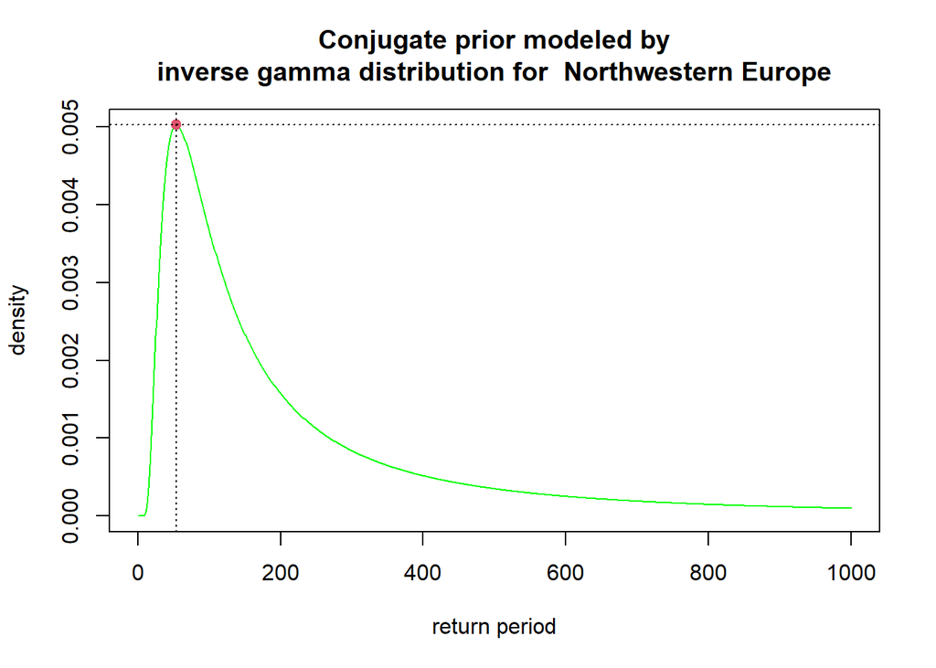

```
                                  Figure 2.
```

```r
# plot
# par(mfrow=c(2,1))

plot(theta, conj_pr_kE, main = "Conjugate prior modeled by
inverse gamma distribution for  Northwestern Europe", ylab="density",
     xlab="return period",    type = "l",col="green" )
points(theta[max_kE],conj_pr_kE[max_kE], col=2, pch =19 )
abline(h=conj_pr_kE[max_kE], lty=3)
abline(v=theta[max_kE], lty=3)
```

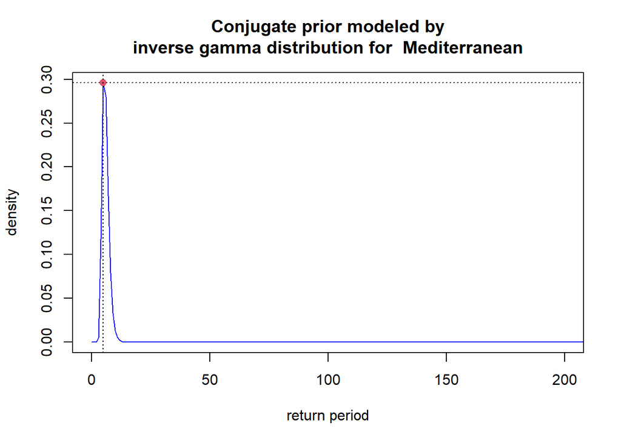

```
                                        Figure 3.
```

```r
plot(theta, conj_pr_kM, main = "Conjugate prior modeled by
inverse gamma distribution for  Mediterranean", ylab="density",
xlab="return period",    type = "l", col="blue", xlim =c(0, 200))
points(theta[max_kM],conj_pr_kM[max_kM], col=2, pch =19 )
abline(h=conj_pr_kM[max_kM], lty=3)
abline(v=theta[max_kM], lty=3)
```

# Task 3. Importance sampling II.

## Problem set.

1. Compute the mean, the variance and the pdf with an importance sampling.
2. Compare with theoretical results.

## Initial preparations.

One considers the following case:

Let $X \sim Beta(\alpha = 3, \beta = 7)$be the proportion of Ilmenite grains in rutiles in a heavy mineral concentrate, domain(X)=(a; b) bounded. Target distribution $f_X(x)$ is difficult to simulate, but reference model $g_X(x)$ easy to simulate, and $f_X(x)=g_X(x)$ cheap to compute for each x.

## Theoretical background.

Importance sampling is a general method for estimating properties of a particular distribution. One generates samples through a different distribution than the distribution of interest.

## Workflow.

### Sample generation.

One begins with generating samples from uniform distribution $U \sim Unif(a,b)$.

```r
# Create sample of uniform distribution
u = runif(5000)
```

### Set up of beta distribution parameters and computation of weights.

- Beta distribution $X \sim Beta(\alpha, \beta)$

```r
# parameters for g(x)
alpha_gx = 0.5
beta_gx = 0.5

# parameters for f(x)
alpha_fx = 3
beta_fx = 7

# compute weights
w = dbeta(u, shape1 = alpha_fx, shape2 = beta_fx)/dbeta(u, shape1 = alpha_gx, shape2 = beta_gx)
# integrate
w = w / sum(w)
```

### Computation of mean value and variance through Monte Carlo approximation .

Monte Carlo approximation is $\widehat{T(x)} = \sum^S_{s=1} w_sT(u_s)$

- Theoretical mean is $E[X] = \dfrac{a}{(a+b)}$

One can approximate the expected value $E[X]$ using sample mean.

```r
# Mean estimate and true mean
mu_E = u %*% w
mu_t = alpha_fx / (alpha_fx + beta_fx)
(paste("Approximation of expected value: ",mu_E))
```

```
## [1] "Approximation of expected value:  0.319039377143465"
```

```r
(paste("Theoretical expected value: ",mu_t))
```

```
## [1] "Theoretical expected value:  0.3"
```

Consequently, theoretical variance :

- $Var[X] = \dfrac{ab}{(a+b)^2 (a+b+1)}$

```r
# Variance approximation and true variance
var_E = (u-c(mu_E))^2 %*% w
var_t = (alpha_fx * beta_fx)/((alpha_fx + beta_fx)^2*(alpha_fx + beta_fx+1)) # true
(paste("Variance approximation: ",var_E))
```

```
## [1] "Variance approximation:  0.0178540676437577"
```

```r
(paste("True variance: ",var_t))
```

```
## [1] "True variance:  0.0190909090909091"
```

### Kernel density estimate.

Then one computes kernel density estimate in order to compare it with results of MC approximation.

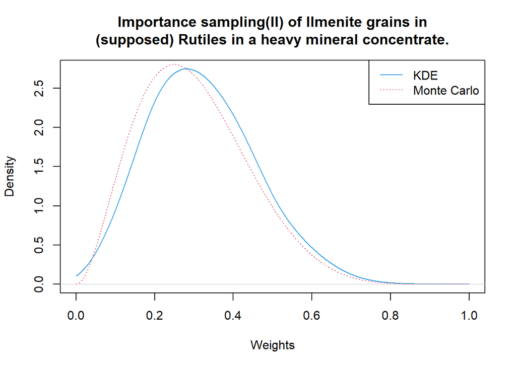

```
                                  Figure 4.
```

```r
# density
dd = density(u, weights = w, from=0, to=1)

#Plot KDE
plot(dd, xlab = "Weights", ylab="Density",
main = "Importance sampling(II) of Ilmenite grains in
(supposed) Rutiles in a heavy mineral concentrate.", lty=1,col=4)

# Plot MC
lines(dd$x, dbeta(dd$x, shape1 = alpha_fx, shape2 = beta_fx), lty=3,col=2)
legend("topright", col = c(4,2),lty = c(1,3), c("KDE", "Monte Carlo") )
```

One can observe some discrepancies between distributions, more significant than in case Importance sampling(I),though it’s pretty close. The plot is presented below. That leads to the conclusion that importance sampling(I) is a little bit more reliable.

Also setting of seed as well as parameters alpha and beta affect on difference between the curves.

```r
un = runif(5000)
wf = dbeta(un, shape1 = alpha_fx, shape2 = beta_fx)
wf = wf/sum(wf)
(mn=un %*% wf)
```

```
##           [,1]
## [1,] 0.3049643
```

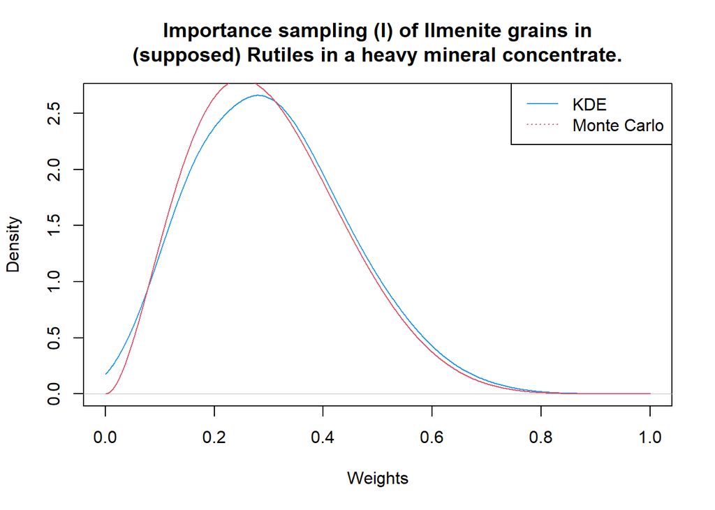

```
                                Figure 5.
```

```r
ddf = density(un, weights = wf, from=0, to=1)
plot(ddf, xlab = "Weights", ylab="Density",
     main = "Importance sampling (I) of Ilmenite grains in
(supposed) Rutiles in a heavy mineral concentrate.", lty=1,col=4)
lines(ddf$x, dbeta(ddf$x, shape1 = 3, shape2 = 7), col=2)
legend("topright", col = c(4,2),lty = c(1,3), c("KDE", "Monte Carlo") )
```

# Task 4. Markov Chain Monte Carlo(MCMC).

## Problem set.

Give confidence intervals for the arithmetic mean and the population variability of X, assuming $Y = ln(X) ∼ N(µ; σ^2)$

## Initial preparations.

Provided data consists of :

- 30 measurements of $X = \{ppm\quad Cd\quad in\quad Sphalerite\}$
- log-mean $\mu_y = 3.442$
- log-variance $\sigma^2_y = 2.182$

```r
# setup
n = 30
ln_mean = 3.442
ln_var = 2.182
```

## Theoretical background.

Markov Chain Monte Carlo simulation unites a family of algorithms for systematic random sampling from high-dimensional(multivariate) probability distributions.

There’s a group of algorithms of MCMC, but here Gibbs Sampling algorithm is considered. The idea of that approach is to construct a Markov Chain where the probability of next sample(next state) is computed as the conditional probability given the prior. This algorithm helps to simplify calculations in case of multivariate distribution. Because such sampling of such joint distribution is difficult, one computes discrete conditional distribution sampling of $p(x|y)$.

One can describe the process by following steps:

1. Initialize $(x^0 , y^0)$
2. keep variable $y^0$ fixed then sample $x^{1} \sim p(x^{1}|y^0)$
3. carry on with the second step and sample for $y^1 \sim p(y^1|x^1)$
4. Run chain for n steps until it reaches its stationary distribution.
5. Upon convergence, all additional steps draw from the stationary distribution $p(\theta|x)$.

## Workflow.

### MC sequence.

One starts with defining MC sequence by random initialization:

$\tau^{0} = \frac{1}{2\sigma^2}$

```r
# setup
n = 30
ln_mean = 3.442
ln_var = 2.182

# define MC steps
iters = 5000

# exponentiate var
vr = exp(ln_var)

# construct an empty matrix of results for iterations
# init y0 and tau - Markov chain sequence
y = rep(0.0, iters)
tau = rep(0.0, iters)

# set the value of the first element
tau[1] = round(1 / (2*vr),3)
```

### Gibbs sampling algorithm.

Then one calculates through n iterations (large enough, here 5000 times). Normal and gamma distributions are used to simulate conditional probability. Each loop iteration is described by sequence below:

- draw a sample of $\mu^{k+1} | \tau^k \quad \sim N(\overline{y}; \dfrac{1}{N\tau^k})$ then assign it to $y^1$
- draw a sample of $\tau^{k+1}| \mu^{k+1} \sim \Gamma(a=\dfrac{N}{2;} r=SSQ)$ then assign it to $\tau^1$ where $SSQ = ((N − 1)s_y^2 + N(\mu^{k+1} − \overline{y})^2)^{−1}$

```r
# Gibbs sampling

i = 2 # or use for{} but end with i=2:(iters - 1)
while (i<iters) {
  mu = ln_mean
  sigma = sqrt(1/(2*n*tau[i-1]))
  y[i] = rnorm(1,mu, sigma )

  SSQ = ((n-1)* ln_var + n*(y[i] - ln_mean)**2)
  a = n/2
  r = SSQ
  tau[i] = rgamma(n=1, shape = a, scale = r )
  i=i+1
}
# Describe tau and y
print("Tau:")
```

```
## [1] "Tau:"
```

```r
summary(tau)
```

```
##    Min. 1st Qu.  Median    Mean 3rd Qu.    Max.
##     0.0   781.9   928.1   949.9  1097.8  1987.0
```

```r
print("Y:")
```

```
## [1] "Y:"
```

```r
summary(y)
```

```
##    Min. 1st Qu.  Median    Mean 3rd Qu.    Max.
##   0.000   3.439   3.442   3.441   3.445   3.756
```

### The visualization before burn=in and thinning.

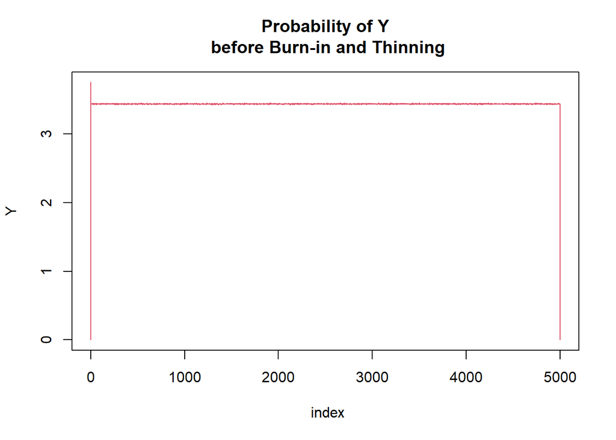

```
                                    Figure 6.
```

```r
# Visualization

#par(mfrow=c(2,1))
plot(y, xlab =" index", ylab = "Y",col=2,type = "l",
     main = "Probability of Y\n before Burn-in and Thinning")
```

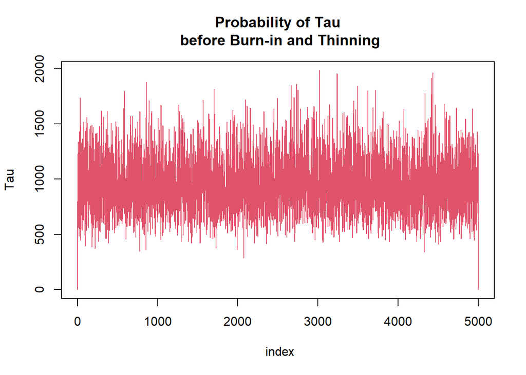

```
                              Figure 7.
```

```r
plot(tau, xlab =" index", ylab = "Tau",col=2,type = "l",
     main = "Probability of Tau\n before Burn-in and Thinning")
```

### Burn-in and thinning.

One uses burn-in technique to throw away some iterations at the start of MCMC. That helps to get rid of influence of the initial value.

The idea behind thinning is to pick separate points from sample at each iteration step. One separates the points from Markov chain, thus the dependence is reduced and sample becomes independent.

```r
# Burn-in and thinning
# Burn-in effect by removing the first k elements
# thinning effect with 20 steps
k=iters/25 +1
step_sz = 20
tk = seq(from= k, to=iters, by=step_sz)
tk
```

```
##   [1]  201  221  241  261  281  301  321  341  361  381  401  421  441  461  481
##  [16]  501  521  541  561  581  601  621  641  661  681  701  721  741  761  781
##  [31]  801  821  841  861  881  901  921  941  961  981 1001 1021 1041 1061 1081
##  [46] 1101 1121 1141 1161 1181 1201 1221 1241 1261 1281 1301 1321 1341 1361 1381
##  [61] 1401 1421 1441 1461 1481 1501 1521 1541 1561 1581 1601 1621 1641 1661 1681
##  [76] 1701 1721 1741 1761 1781 1801 1821 1841 1861 1881 1901 1921 1941 1961 1981
##  [91] 2001 2021 2041 2061 2081 2101 2121 2141 2161 2181 2201 2221 2241 2261 2281
## [106] 2301 2321 2341 2361 2381 2401 2421 2441 2461 2481 2501 2521 2541 2561 2581
## [121] 2601 2621 2641 2661 2681 2701 2721 2741 2761 2781 2801 2821 2841 2861 2881
## [136] 2901 2921 2941 2961 2981 3001 3021 3041 3061 3081 3101 3121 3141 3161 3181
## [151] 3201 3221 3241 3261 3281 3301 3321 3341 3361 3381 3401 3421 3441 3461 3481
## [166] 3501 3521 3541 3561 3581 3601 3621 3641 3661 3681 3701 3721 3741 3761 3781
## [181] 3801 3821 3841 3861 3881 3901 3921 3941 3961 3981 4001 4021 4041 4061 4081
## [196] 4101 4121 4141 4161 4181 4201 4221 4241 4261 4281 4301 4321 4341 4361 4381
## [211] 4401 4421 4441 4461 4481 4501 4521 4541 4561 4581 4601 4621 4641 4661 4681
## [226] 4701 4721 4741 4761 4781 4801 4821 4841 4861 4881 4901 4921 4941 4961 4981
```

```r
tau_tk = tau[tk]
y_tk = y[tk]
```

Now it’s reasonable to visualize the results to compare before- and after-

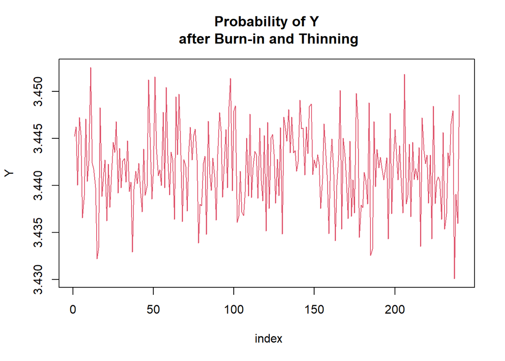

```
                              Figure 8.
```

```r
#par(mfrow=c(2,1))
plot(y_tk, xlab =" index", ylab = "Y",col=2,type = "l",
     main = "Probability of Y\n after Burn-in and Thinning")
```

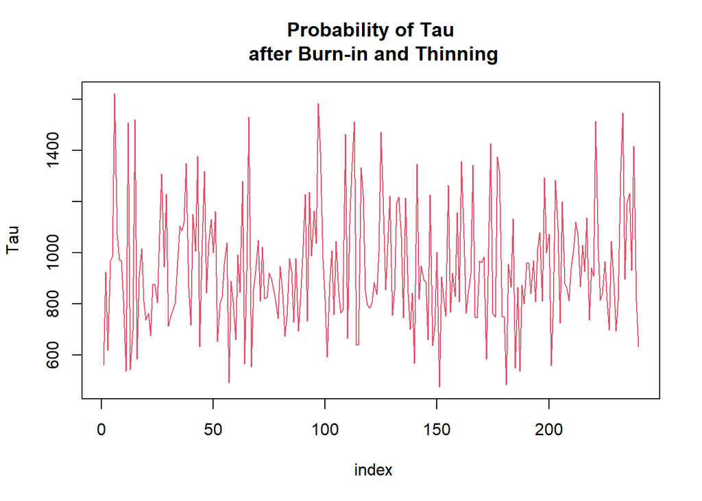

```
                          Figure 9.
```

```r
plot(tau_tk, xlab =" index", ylab = "Tau",col=2,type = "l",
     main = "Probability of Tau\n after Burn-in and Thinning")
```

Comparing figures yields the conclusion that the impact of the initial value and the periodicity of the realizations have been drastically decreased.

### Expectation value and variance.

Expectation value and variance are computed through:

- $E[X]= exp(\mu_y + \dfrac{\sigma^2_y}{2})$
- $Var[X] = (E[X])^2 * (exp(\sigma^2_y) - 1)$

```r
# Confidence intervals for MC sample
sigma_sqr = 1 / (2 * tau)

E_x = exp(y + 0.5 * sigma_sqr)
Var_x = E_x^2 *(exp(sigma_sqr) - 1)

print("Expectation value: ")
```

```
## [1] "Expectation value: "
```

```r
summary(E_x)
```

```
##    Min. 1st Qu.  Median    Mean 3rd Qu.    Max.
##   30.77   31.17   31.26     Inf   31.35     Inf
```

```r
print("Variance: ")
```

```
## [1] "Variance: "
```

```r
summary(Var_x)
```

```
##    Min. 1st Qu.  Median    Mean 3rd Qu.    Max.
##  0.2447  0.4451  0.5266     Inf  0.6265     Inf
```

```r
quantiles = c(0.025, 0.05, 0.95, 0.975)

# Confidence intervals for E[X]
q_E_x = quantile(E_x,quantiles)
print(" Confidence intervals for E[X]: ")
```

```
## [1] " Confidence intervals for E[X]: "
```

```r
print(q_E_x)
```

```
##     2.5%       5%      95%    97.5%
## 30.99564 31.03571 31.48530 31.52740
```

```r
# Confidence intervals for Var[X]
q_Var_x = quantile(Var_x,quantiles)
print(" Confidence intervals for Var[X]: ")
```

```
## [1] " Confidence intervals for Var[X]: "
```

```r
print(q_Var_x)
```

```
##      2.5%        5%       95%     97.5%
## 0.3283008 0.3513838 0.8370624 0.9186423
```